# digitalLDSorteR: R package for deconvolution of bulk RNA-seq samples based on Deep Learning

First Author and Second Author

First Author's Affiliation  
Second Author's Affiliation

corresponding@author.com

7 September 2020

#### Abstract

Introduction of main functionalities of digitalDLSorteR. This package has two goals. First, to offer a set of pre-trained deconvolution models for the prediction of cell composition in bulk RNA-seq samples quickly and easily. Second, digitalDLSorteR provides all the necessary functions for the construction of new deconvolution models from scRNA-seq data. In this vignette, both ways of use are explained using data loaded into the package.

#### Package

digitalDLSorteR 0.1.0

# 1 Introduction to *digitalDLSorteR* package

*digitalDLSorteR* is an R package that implements a Deep Learning based method to enumerate and quantify the cell type composition of bulk RNA-seq samples. Our method makes use of Deep Neural Network (DNN) models to adjust any cell type composition starting from single-cell RNA-seq (scRNA-seq) data.

The rationale of the method consists in a process that starts from scRNA-seq data and, after a few steps, a Deep Neural Network (DNN) model is trained with simulated bulk RNA-seq samples whose cell composition is known. The trained model is able to deconvolve any bulk RNA-seq sample by determining the proportion of the different cell types present in it. The main advantage of this method is the possibility of building deconvolution models trained with real data which comes from certain biological environments. For example, for quantifying the proportion of tumor infiltrated lymphocytes (TILs) in breast cancer, by following this protocol you can obtain a specific model for this type of samples. This fact overcomes the limitation of other methods, since stromal and immune cells change significantly their profiles depending on the tissue and disease context.

The package can be used in two ways: for deconvolving bulk RNA-seq samples using a pre-trained model provided by us or for building your own models trained from your own scRNA-seq samples. These new models may be published in order to make them available for other users that work with similar data (e.g. neural environment, prostate cancer environment, etc.). For the moment, the available models allows the deconvolution of TILs from breast cancer classified by our team.

# 2 Installation

*digitalDLSorteR* only has been tested on Linux, so, for the moment, we recomend its installation only on Linux distributions. This is a development version, so only it is possible its installation from GitHub by `devtools`.

```r
if (!requireNamespace("devtools", quietly = TRUE))
    install.packages("devtools")
devtools::install_github("diegommcc/digitalDLSorteR")
```

*digitalDLSorteR* is based on DNN models. To do this, it uses [Keras](https://cloud.r-project.org/web/packages/keras/index.html) package available from CRAN, a high-level neural networks API implemented on Python. Keras R version works as interface between these two languages by using [reticulate](https://cran.r-project.org/web/packages/reticulate/index.html) package, so, during the installation, Keras requires that you provdes a Python interpreter for working. We recommend the use of conda environments to provide a Python interpreter with all dependencies covered. If you have a conda environment compatible with Keras requirements, the package will find it automatically. If not, Keras package will create a new environment named `r-reticulate` There are other methods for installing a functionally back-end, see https://keras.rstudio.com/reference/install_keras.html for more details.

```r
install.packages("keras")
library(keras)
install_keras(method = "conda") # other options are available
```

This is the default CPU-based installation, but it is possible a more customized installation. See https://tensorflow.rstudio.com/installation/ and https://keras.rstudio.com/reference/install_keras.html.

# 3 Using pre-trained models for deconvolving bulk RNA-seq samples

This is the simplest way to use the method. Only it is necessary a bulk RNA-seq sample matrix with genes as rows (in symbol notation) and samples as columns and the package returns the predicted cell composition of each sample. As mentioned above, for the moment, only one model for deconvolving breast cancer samples is available. This model was generated from GSE75688 (Chung et al., 2017) data set whose cells were characterized by our team. It is oriented to the quantification of immune cell types in cancer samples. This presents advantages over other tools, since it has been trained from scRNA-seq data from the tumor itself, preserving the specific characteristics of the tumor microenvironment as opposite to other approaches in which cells were isolated from blood. Moreover, we have provided two resolution levels for the deconvolution task:

- First, a model trained with cell types characterized at high resolution level: ER+, HER2+, ER+/HER2+, TNBC, stromal, monocyte, TCD4mem (memory CD4+ T cell), BGC (germinal center B cell), Bmem (memory B cell), DC (dendritic cell), macrophage, TCD8 (CD8+ T cell) and TCD4reg (regulatory CD4+ T cell). Note that intrinsic subtypes of breast cancer are taken into account independently.
- Second, a model trained with cell types less specific: B cells, T CD4+ cells, T CD8+ cells, monocytes, dendritic cells, stromal cells and tumor cells. Each one is a more general group which includes the above cell types.

For more information about the data set, see the provided documentation in the package.

## 3.1 Package usage example

Using the package in this way, it is only necessary to load the samples that you want to deconvolve in R and use them as `data` argument for `deconvDigitalDLSorter` function. This object must be a `matrix` or a `data.frame` with genes as rows and samples as columns. Genes must be annotated as SYMBOL, since the model was trained with this notation. Data must be TPMs, since model was trained with this type of data. If data is not normalized, set `normalize` argument equal to `TRUE` (by default). Moreover, you must specify the model that will be used in `model` argument. In this example, we are going to deconvolve a small subset of TCGA samples from breast sample. We are using the generic version (`model = "breast.chung.generic"`), but it is also possible the use of specific (`model = "breast.chung.specific"`):

```r
library(digitalDLSorteR)

# this line is to ensure compatibility with all machines
tensorflow::tf$compat$v1$disable_eager_execution()

deconvResults <- deconvDigitalDLSorter(
  data = TCGA.breast.small,
  model = "breast.chung.generic",
  normalize = TRUE
)

head(deconvResults)
##                                           Tumor    Stromal   Monocyte
## X05a734dd.0260.47ca.84a1.51f5b0d4711b 0.4543931 0.01361190 0.02854882
## X8db035be.6b8b.438d.9f3f.94dcf58c0d86 0.5326535 0.01299661 0.01747806
## X7fd26291.9f69.4b1e.8492.8390e3a24ff5 0.4955306 0.01381174 0.03096530
## X883057bf.5e2a.4009.8445.25273350ace2 0.5246924 0.01387618 0.03006849
## X59dee04a.f428.44d3.ae59.686adb65e543 0.5235595 0.01424065 0.02697111
## cf8f56c2.7560.4342.95a4.766c689d2890  0.5882370 0.01033140 0.02563650
##                                           TcellCD4        Bcell
## X05a734dd.0260.47ca.84a1.51f5b0d4711b 0.0008882938 1.365591e-05
## X8db035be.6b8b.438d.9f3f.94dcf58c0d86 0.0008811795 1.813403e-05
## X7fd26291.9f69.4b1e.8492.8390e3a24ff5 0.0018600314 4.743740e-06
## X883057bf.5e2a.4009.8445.25273350ace2 0.0011304716 1.235964e-05
## X59dee04a.f428.44d3.ae59.686adb65e543 0.0011663649 1.124400e-05
## cf8f56c2.7560.4342.95a4.766c689d2890  0.0010588461 1.506462e-05
##                                             DCs  TcellCD8
## X05a734dd.0260.47ca.84a1.51f5b0d4711b 0.3372709 0.1652734
## X8db035be.6b8b.438d.9f3f.94dcf58c0d86 0.3046368 0.1313357
## X7fd26291.9f69.4b1e.8492.8390e3a24ff5 0.3261853 0.1316423
## X883057bf.5e2a.4009.8445.25273350ace2 0.2976526 0.1325674
## X59dee04a.f428.44d3.ae59.686adb65e543 0.2953200 0.1387311
## cf8f56c2.7560.4342.95a4.766c689d2890  0.2573796 0.1173415
```

`deconvDigitalDLSorter` returns a data frame with the provided samples ($k$) in rows and cell types considered by the model ($j$) in columns. Each entry corresponds with the proportion of $k$ cell type in $i$ sample. In order to evaluate the results quickly by a bar plot, you can use `barplotCellTypes` function as follows:

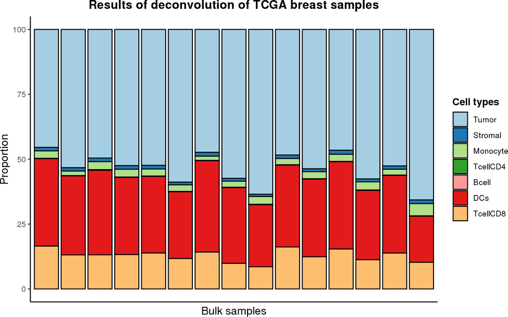

```r
barPlotCellTypes(
  deconvResults,
  rm.x.text = TRUE,
  color.line = "black",
  title = "Results of deconvolution of TCGA breast samples"
)
```